# Topic Modelling

Subhankar, Rohan, Sourabh

May 24, 2017

**Subhankar Pattnaik** *- 71710059* **Rohan Sarin** *- 71710071* **Sourabh Singla** *- 71710091*

## This project runs Topic Model on different subjects thereby separating the tokens on basis of subjects producing wordclouds, cogs etc. as results.

```r
rm(list=ls())                   # Clear workspace

#--------------------------------------------------------#
# Step 0 - Assign Library & define functions             #
#--------------------------------------------------------#
try(require(maptpx) || install.packages("maptpx"))
```

```
## [1] TRUE
```

```r
try(require(text2vec) || install.packages("text2vec"))
```

```
## [1] TRUE
```

```r
try(require(igraph) || install.packages("igraph"))
```

```
## [1] TRUE
```

```r
library(text2vec)
library(data.table)
library(stringr)
library(tm)
library(RWeka)
library(tokenizers)
```

```r
library(slam)
library(wordcloud)
library(igraph)
library(maptpx)
```

```r
text.clean = function(x)                    # text data
{ require("tm")
  x  =  gsub("<.*?>", " ", x)               # regex for removing HTML tags
  x  =  iconv(x, "latin1", "ASCII", sub="") # Keep only ASCII characters
  x  =  gsub("[^[:alnum:]]", " ", x)        # keep only alpha numeric
  x  =  tolower(x)                          # convert to lower case characters
  x  =  removeNumbers(x)                    # removing numbers
  x  =  stripWhitespace(x)                  # removing white space
  x  =  gsub("^\\s+|\\s+$", "", x)          # remove leading and trailing white space
  return(x)
}
```

```r
distill.cog = function(mat1, # input TCM ADJ MAT
                       title, # title for the graph
                       s,    # no. of central nodes
                       k1){  # max no. of connections

  a = colSums(mat1) # collect colsums into a vector obj a
  b = order(-a)     # nice syntax for ordering vector in decr order

  mat2 = mat1[b,b]  #

  diag(mat2) =  0

  ## +++ go row by row and find top k adjacencies +++ ##

  wc = NULL

  for (i1 in 1:s){
    thresh1 = mat2[i1,][order(-mat2[i1, ])[k1]]
    mat2[i1, mat2[i1,] < thresh1] = 0   # wow. didn't need 2 use () in the subset here.
    mat2[i1, mat2[i1,] > 0 ] = 1
    word = names(mat2[i1, mat2[i1,] > 0])
    mat2[(i1+1):nrow(mat2), match(word,colnames(mat2))] = 0
    wc = c(wc,word)
  } # i1 loop ends


  mat3 = mat2[match(wc, colnames(mat2)), match(wc, colnames(mat2))]
  ord = colnames(mat2)[which(!is.na(match(colnames(mat2), colnames(mat3))))]  # removed any NAs from the list
  mat4 = mat3[match(ord, colnames(mat3)), match(ord, colnames(mat3))]
  graph <- graph.adjacency(mat4, mode = "undirected", weighted=T)    # Create Network object
  graph = simplify(graph)
  V(graph)$color[1:s] = "green"
  V(graph)$color[(s+1):length(V(graph))] = "pink"

  graph = delete.vertices(graph, V(graph)[ degree(graph) == 0 ])

  plot(graph,
       layout = layout.kamada.kawai,
      main = title)

  } # func ends
```

```r
#--------------------------------------------------------#
# Step 1 - Reading text data                             #
#--------------------------------------------------------#

search_terms = c('Football','Science','Politics')

file.mi = read.csv(paste0("Y:\\Knowledge Repository\\ISB\\TABA\\TABA Group Assignment-20170426\\Football google search.csv"))
file.lin = read.csv(paste0("Y:\\Knowledge Repository\\ISB\\TABA\\TABA Group Assignment-20170426\\Science google search.csv"))
file.der = read.csv(paste0("Y:\\Knowledge Repository\\ISB\\TABA\\TABA Group Assignment-20170426\\Politics google search.csv"))
```

```r
file.mi = file.mi[!is.na(file.mi$text)|file.mi$text != '',]

file.lin = file.lin[!is.na(file.lin$text)|file.lin$text != '',]

file.der = file.der[!is.na(file.der$text)|file.der$text != '',]

n = min(nrow(file.mi),nrow(file.lin),nrow(file.der))

data = data.frame(id = 1:n,
                      text1 = file.mi$text[1:n],
                      text2 = file.lin$text[1:n],
                      text3 = file.der$text[1:n],
                      stringsAsFactors = F)
data$text = paste(data$text1,data$text2,data$text3)
```

```r
dim(data)
```

```
## [1] 57  5
```

```r
# Read Stopwords list
stpw1 = readLines('https://raw.githubusercontent.com/sudhir-voleti/basic-text-analysis-shinyapp/master/data/stopwords.txt') # stopwords list from git'
stpw2 = tm::stopwords('english') # tm package stop word list; tokenizer package has the same name function
comn  = unique(c(stpw1, stpw2))  # Union of two list #'solid state chemistry','microeconomics','linguistic'
stopwords = unique(gsub("'"," ",comn))  # final stop word lsit after removing punctuation
```

```r
x  = text.clean(data$text)             # pre-process text corpus
x  =  removeWords(x,stopwords)         # removing stopwords created above
x  =  stripWhitespace(x)               # removing white space
```

```r
#--------------------------------------------------------#
####### Create DTM using text2vec package                #
#--------------------------------------------------------#

t1 = Sys.time()

tok_fun = word_tokenizer

it_0 = itoken( x,
               #preprocessor = text.clean,
               tokenizer = tok_fun,
               ids = data$id,
               # progressbar = T
               )

vocab = create_vocabulary(it_0,
                          #ngram = c(2L, 2L)
                          #stopwords = stopwords
)

pruned_vocab = prune_vocabulary(vocab,
                                term_count_min = 10)
# doc_proportion_max = 0.5,
# doc_proportion_min = 0.001)

vectorizer = vocab_vectorizer(pruned_vocab)

dtm_0  = create_dtm(it_0, vectorizer)

# Sort bi-gram with decreasing order of freq
tsum = as.matrix(t(rollup(dtm_0, 1, na.rm=TRUE, FUN = sum))) # find sum of freq for each term
tsum = tsum[order(tsum, decreasing = T),]       #terms in decreasing order of freq
head(tsum)
```

```
##  science football     news politics   league    video
##     1558     1496      942      857      836      598
```

```r
tail(tsum)
```

```
##     happen   delivers     upheld apparently    covered  debunking
##         10         10         10         10         10         10
```

```r
# select Top 1000 bigrams to unigram
if (length(tsum) > 1000) {n = 1000} else {n = length(tsum)}
tsum = tsum[1:n]

#-------------------------------------------------------
# Code bi-grams as unigram in clean text corpus

text2 = x
text2 = paste("",text2,"")

pb <- txtProgressBar(min = 1, max = (length(tsum)), style = 3) ; i = 0

for (term in names(tsum)){
  i = i + 1
  focal.term = gsub("_", " ",term)        # in case dot was word-separator
  replacement.term = term
  text2 = gsub(paste("",focal.term,""),paste("",replacement.term,""), text2)
  # setTxtProgressBar(pb, i)
}


it_m = itoken(text2,
              # preprocessor = text.clean,
              tokenizer = tok_fun,
              ids = data$id,
              progressbar = T
              )

vocab = create_vocabulary(it_m
                          #ngram = c(2L, 2L),
                          #stopwords = stopwords
)
pruned_vocab = prune_vocabulary(vocab,
                                term_count_min = 1)
# doc_proportion_max = 0.5,
# doc_proportion_min = 0.001)

vectorizer = vocab_vectorizer(pruned_vocab)

dtm_m  = create_dtm(it_m, vectorizer)
dim(dtm_m)
```

```
## [1]    57 24050
```

```r
dtm = as.DocumentTermMatrix(dtm_m, weighting = weightTf)
print(difftime(Sys.time(), t1, units = 'sec'))
```

```
## Time difference of 33.21389 secs
```

```r
# some basic clean-up ops
dim(dtm)
```

```
## [1]    57 24050
```

```r
a0 = apply(dtm, 1, sum)   # apply sum operation to dtm's rows. i.e. get rowSum
dtm = dtm[(a0 > 5),]    # retain only those rows with token rowSum >5, i.e. delete empty rows
dim(dtm); rm(a0)        # delete a0 object
```

```
## [1]    57 24050
```

```r
a0 = apply(dtm, 2, sum)   # use apply() to find colSUms this time
dtm = dtm[, (a0 > 6)]     # retain only those terms that occurred > 4 times in the corpus
# dtm = dtm[, (a0 > 4)]     # retain only those terms that occurred > 4 times in the corpus
dim(dtm); rm(a0)
```

```
## [1]   57 4723
```

```r
# view summary wordcloud
a0 = apply(dtm, 2, sum)     # colSum vector of dtm
a0[1:5]                   # view what a0 obj is like
```

```
##      halo      shen   alchemy waterbury     varga
##         9         7        10        10        48
```

```r
a1 = order(as.vector(a0), decreasing = TRUE)     # vector of token locations
a0 = a0[a1]     # a0 ordered asper token locations
a0[1:5]         # view a0 now
```

```
##  science football     news politics   league
##     1558     1496      942      857      836
```

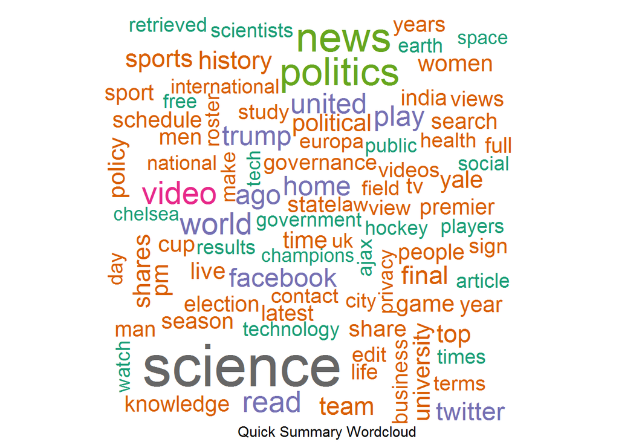

```r
#windows() # opens new image window
wordcloud(names(a0), a0,     # invoke wordcloud() func. Use ?wordcloud for more info
          scale=c(4,1),
          3, # min.freq
          max.words = 100,
          colors = brewer.pal(8, "Dark2"))
title(sub = "Quick Summary Wordcloud")
```

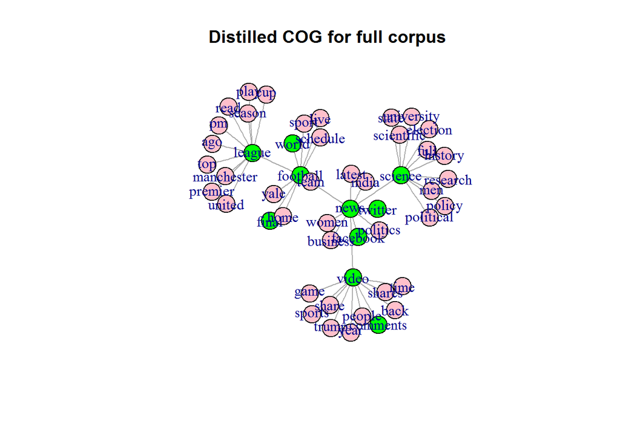

```r
#------------------------------------------------------#
# Step 1a - Term Co-occurance Matrix                             #
#------------------------------------------------------#

pruned_vocab = prune_vocabulary(vocab,
                                term_count_min = 5)

vectorizer = vocab_vectorizer(pruned_vocab, grow_dtm = FALSE, skip_grams_window = 3L)
tcm = create_tcm(it_m, vectorizer)
tcm.mat = as.matrix(tcm)
adj.mat = tcm.mat + t(tcm.mat)

diag(adj.mat) = 0     # set diagonals of the adj matrix to zero --> node isn't its own neighor
a0 = order(apply(adj.mat, 2, sum), decreasing = T)
adj.mat = as.matrix(adj.mat[a0[1:50], a0[1:50]])

# windows()
distill.cog(adj.mat, 'Distilled COG for full corpus',  10,  10)
```

```r
#################################################
## --- Step 2: model based text analytics ------ ###
#################################################

K = 3     # overriding model fit criterion

# -- run topic model for selected K -- #
summary( simfit <- topics(dtm,  K=K, verb=2), nwrd = 12 )
```

```
##
## Estimating on a 57 document collection.
## Fitting the 3 topic model.
## log posterior increase: 2025, 863.8, done. (L = -1071444.9)
##
## Top 12 phrases by topic-over-null term lift (and usage %):
##
## [1] 'ziman', 'cosco', 'aristotelian', 'shin', 'kendra', 'est', 'resource', 'cfb', 'submissions', 'peirce', 'feynman', 'nivia' (61.5)
## [2] 'overs', 'mandelbaum', 'pier', 'permalink', 'manifestos', 'lib', 'wigan', 'dems', 'pledges', 'compilation', 'icc', 'giphy' (25.9)
## [3] 'moines', 'schoellkopf', 'pfl', 'raleigh', 'ithaca', 'lijphart', 'willamette', 'brainyquote', 'finley', 'import', 'conditioning', 'mssd' (12.6)
##
## Dispersion = 3.16
```

```r
rownames1 = gsub(" ", ".", rownames(simfit$theta))
rownames(simfit$theta) = rownames1
```

```r
dim(simfit$theta)   # analogous to factor loadings
```

```
## [1] 4723    3
```

```r
dim(simfit$omega)   # analogous to factor scores
```

```
## [1] 57  3
```

```r
simfit$theta[1:5,]
```

```
##            topic
## phrase                 1            2            3
##   halo      1.388756e-06 2.588730e-04 4.661933e-09
##   shen      3.973970e-09 2.058776e-09 4.470438e-04
##   alchemy   5.210193e-09 2.058776e-09 6.386328e-04
##   waterbury 5.210193e-09 2.058776e-09 6.386328e-04
##   varga     2.086900e-08 2.058776e-09 3.065427e-03
```

```r
simfit$omega[1:5,]
```

```
##         topic
## document            1            2            3
##        1 0.9998408843 0.0000529332 0.0001061825
##        2 0.9991783951 0.0002279327 0.0005936723
##        3 0.0007999251 0.0007453318 0.9984547431
##        4 0.5624259289 0.4355878384 0.0019862327
##        5 0.6641989407 0.2553048700 0.0804961892
```

```r
# ----------------------------------------------------------#
### Step 2a - compute LIFT for all terms across all topics ###
# ----------------------------------------------------------#

tst = round(ncol(dtm)/100)
a = rep(tst,99)
b = cumsum(a);rm(a)
b = c(0,b,ncol(dtm))

ss.col = c(NULL)
for (i in 1:(length(b)-1)) {
  tempdtm = dtm[,(b[i]+1):(b[i+1])]
  s = colSums(as.matrix(tempdtm))
  ss.col = c(ss.col,s)
  # print(i)
}

head(ss.col)
```

```
##      halo      shen   alchemy waterbury     varga   sherrod
##         9         7        10        10        48        11
```

```r
theta = simfit$theta
lift = theta*0;       # lift will have same dimn as the theta matrix

sum1 = sum(dtm)
pterms = ss.col/sum1     # each column's marginal occurrence probability

head(pterms)
```

```
##         halo         shen      alchemy    waterbury        varga
## 6.424808e-05 4.997073e-05 7.138676e-05 7.138676e-05 3.426564e-04
##      sherrod
## 7.852544e-05
```

```r
for (i in 1:nrow(theta)){
  for (j in 1:ncol(theta)){
    ptermtopic = 0; pterm = 0;
    ptermtopic = theta[i, j]
    pterm = pterms[i]
    lift[i, j] = ptermtopic/pterm     # divide each cell by the column's marg. occurr. proby.
  }
}

dim(lift); head(lift, 15)
```

```
## [1] 4723    3
```

```
##             topic
## phrase                  1            2            3
##   halo       2.161553e-02 4.029273e+00 7.256143e-05
##   shen       7.952596e-05 4.119964e-05 8.946112e+00
##   alchemy    7.298542e-05 2.883975e-05 8.946096e+00
##   waterbury  7.298542e-05 2.883975e-05 8.946096e+00
##   varga      6.090356e-05 6.008281e-06 8.946065e+00
##   sherrod    7.159804e-05 2.621795e-05 8.946092e+00
##   courant    6.317459e-05 1.029991e-05 8.946071e+00
##   hartford   6.298664e-05 9.944741e-06 8.946070e+00
##   sportzedge 5.956283e-05 3.474669e-06 8.946062e+00
##   alessi     7.952596e-05 4.119964e-05 8.946112e+00
##   marrow     7.468112e-05 3.204417e-05 8.946100e+00
##   handsome   7.468112e-05 3.204417e-05 8.946100e+00
##   uniteds    1.730684e-05 3.657883e-05 8.946399e+00
##   grush      1.707211e-03 4.081628e+00 7.892573e-05
##   stack      8.002599e-02 3.875676e+00 5.349386e-05
```

```r
lift[25:35,]
```

```
##            topic
## phrase                 1            2            3
##   permalink 1.016359e-04 4.085806e+00 3.157029e-05
##   fridge    1.947020e-02 4.034920e+00 8.333526e-05
##   relays    9.766495e-06 2.404466e-05 8.946438e+00
##   bulldog   1.483398e-05 2.884579e-05 8.946430e+00
##   bibcode   1.413963e-04 3.604941e-05 8.945733e+00
##   labor     1.149398e-04 4.239663e-05 8.945906e+00
##   conf      1.003823e-04 2.059973e-05 8.945902e+00
##   spitting  2.997025e-02 3.910751e+00 2.115378e-01
##   decay     2.525971e-02 4.019708e+00 9.415836e-05
##   nanoscale 6.792936e-03 4.068264e+00 9.461209e-05
##   overs     8.798029e-05 4.085869e+00 6.724905e-05
```

```r
# Generate A censored Lift matrix
censored.lift = lift
for (i in 1:nrow(lift)){
  censored.lift[i,][censored.lift[i,] < max(censored.lift[i,])] = 0   # hard assigning tokens to topics
}
head(censored.lift, 10)
```

```
##             topic
## phrase       1        2        3
##   halo       0 4.029273 0.000000
##   shen       0 0.000000 8.946112
##   alchemy    0 0.000000 8.946096
##   waterbury  0 0.000000 8.946096
##   varga      0 0.000000 8.946065
##   sherrod    0 0.000000 8.946092
##   courant    0 0.000000 8.946071
##   hartford   0 0.000000 8.946070
##   sportzedge 0 0.000000 8.946062
##   alessi     0 0.000000 8.946112
```

```r
#----------------------------------------------------------------#
# Step 2b - Calculate ETA - each document's score on each topic  #
#----------------------------------------------------------------#

t = Sys.time()

if(nrow(dtm) < 100) {k1 = 10} else {k1= 100}   # to avoid machine choking up in v small datasets

tst = ceiling(nrow(dtm)/k1)  # now using 1% of the rows at a time
a = rep(tst, (k1 - 1))
b = cumsum(a);rm(a)    # cumsum() is cumulative sum.
b = c(0, b, nrow(dtm))  # broke the supermassive dtm into chunks of 1% ncol each
  a0 = which(b > nrow(dtm));    # sometimes, rounding errors cause out of bound errors
  if (length(a0) > 0) {b = b[-a0]}

eta.new = NULL
for (i1 in 1:K){

  a2 = c(NULL)
  for (i in 1:(length(b)-1)) {
    tempdtm = dtm[(b[i]+1):(b[i+1]),]
    a = matrix(rep(lift[, i1], nrow(tempdtm)), nrow(tempdtm), ncol(tempdtm), byrow = TRUE)
    a1 = rowSums(as.matrix(tempdtm * a))
    a2 = c(a2, a1); rm(a, a1, tempdtm)
      } # i ends

  eta.new = cbind(eta.new, a2); rm(a2)

  } # i1 ends

Sys.time() - t  # will take longer than lift building coz ncol is v v high now
```

```
## Time difference of 0.2802579 secs
```

```r
rownames(eta.new) = rownames(simfit$omega)
colnames(eta.new) = colnames(simfit$theta)
```

```r
eta.propn = eta.new / rowSums(eta.new)   # calc topic proportions for each document
eta.propn [1:5,]
```

```
##           1          2         3
## 1 0.7883489 0.01904959 0.1926016
## 2 0.7457586 0.03831276 0.2159286
## 3 0.1055182 0.12496905 0.7695127
## 4 0.2829609 0.50691067 0.2101284
## 5 0.3503138 0.34533615 0.3043500
```

```r
df.top.terms = data.frame(NULL)    # can't fit ALL terms in plot, so choose top ones with max loading

k = 3
for (i in 1:k){       # For each topic
  a0 = which(censored.lift[,i] > 1) # terms with lift greator than 1 for topic i
  freq = theta[a0, i] # Theta for terms greator than 1
  freq = sort(freq, decreasing = T) # Terms with higher probilities for topic i

  # Auto Correction -  Sometime terms in topic with lift above 1 are less than 100. So auto correction
  n = ifelse(length(freq) >= 100, 100, length(freq))
  top_word = as.matrix(freq[1:n])

  top.terms = row.names(top_word)
  df.top.terms.t = data.frame(topic = i, top.terms =top.terms, stringsAsFactors = F )
  df.top.terms = rbind(df.top.terms, df.top.terms.t  )

} # i loop ends
```

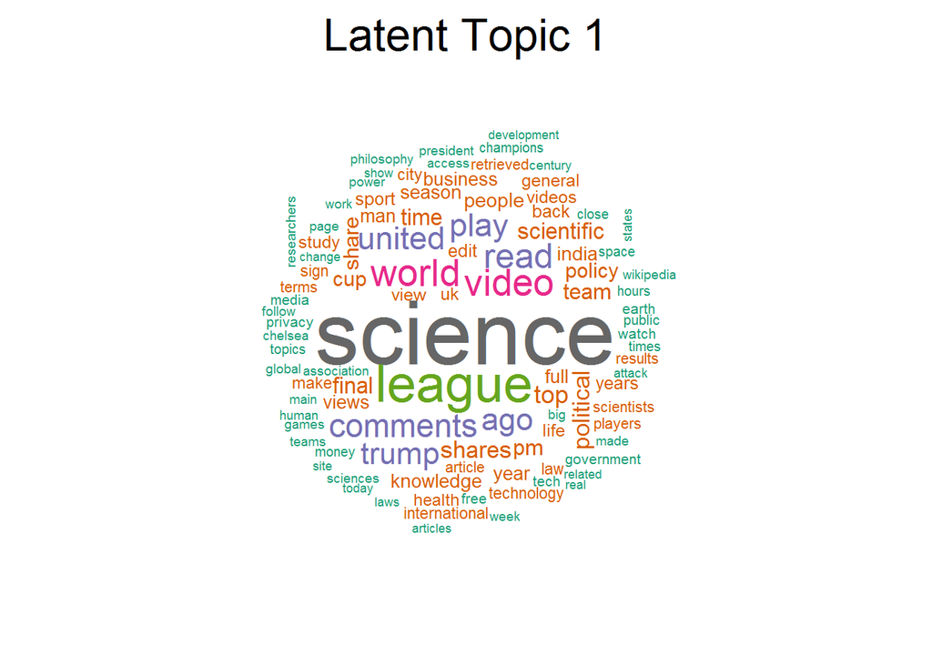

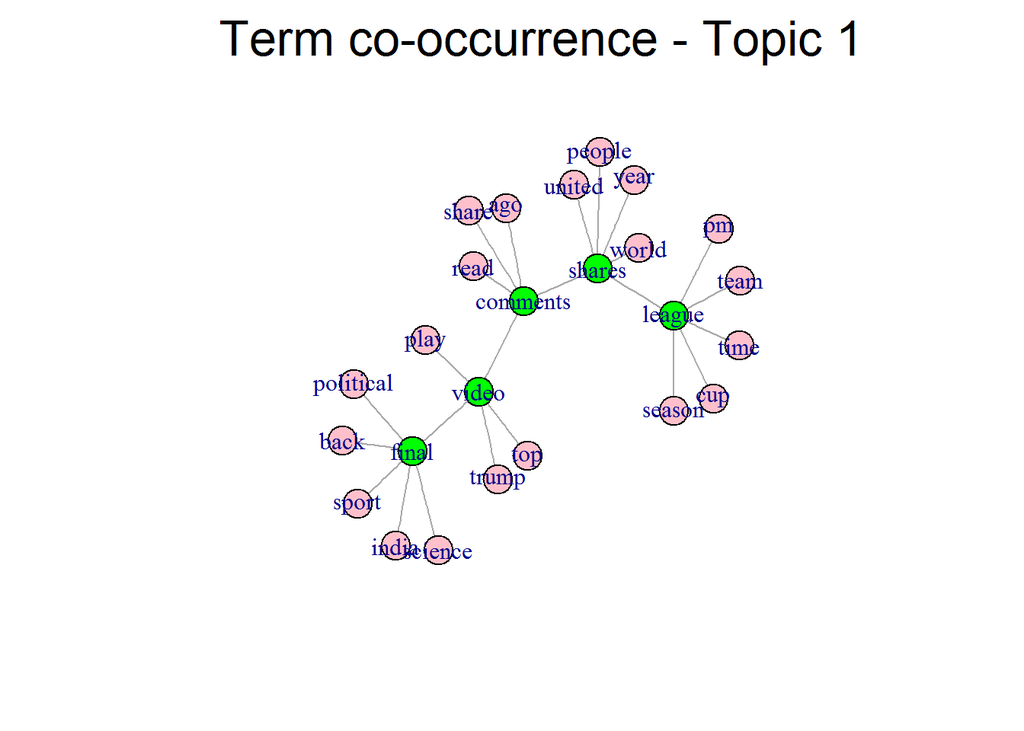

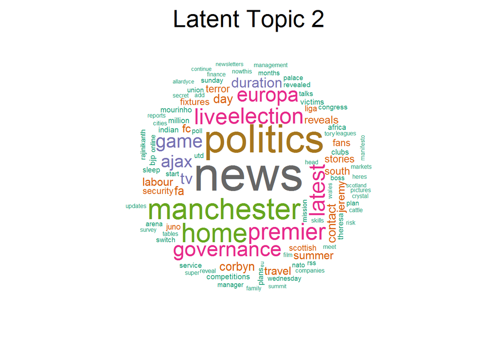

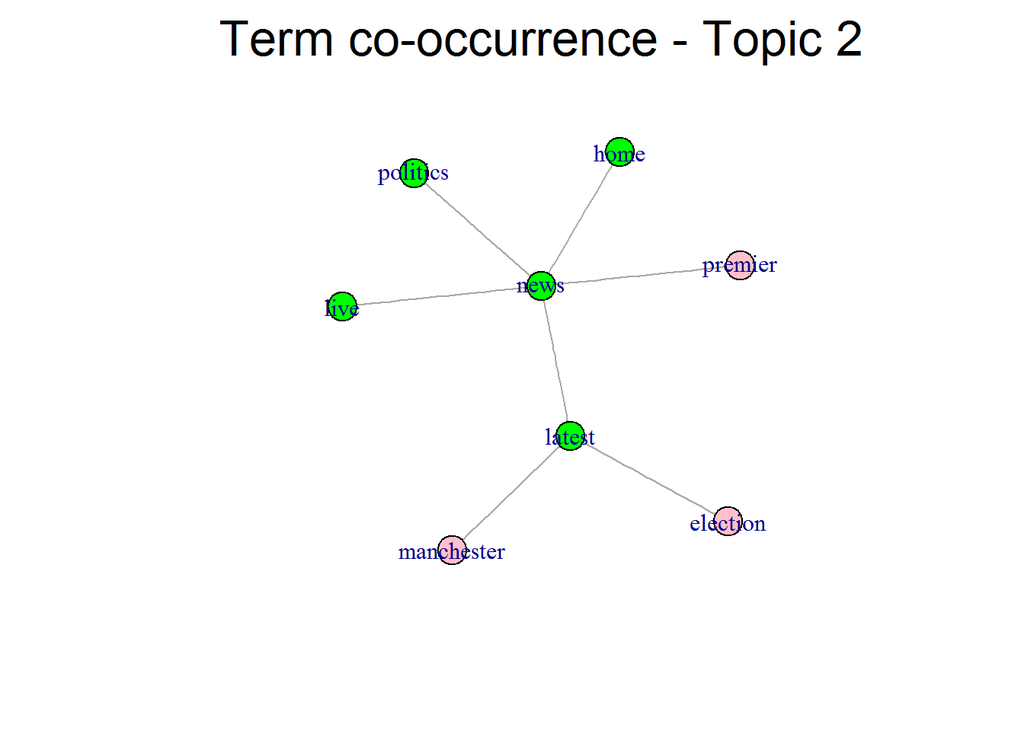

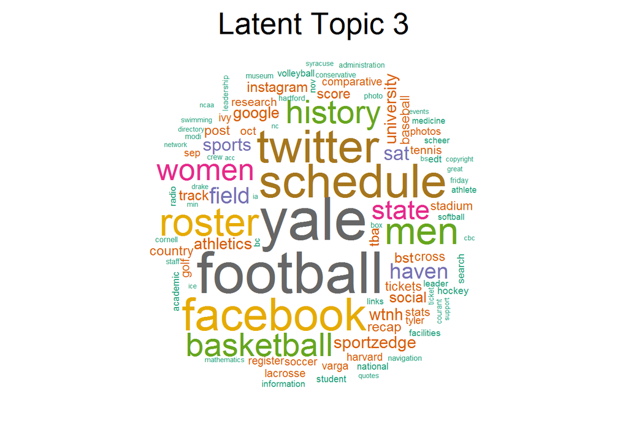

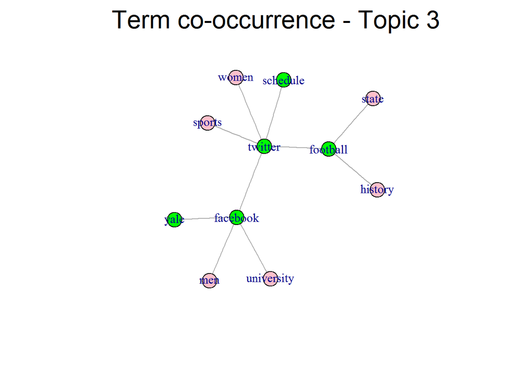

```r
k = 3
for (i in 1:K){       # For each topic

  a0 = which(censored.lift[,i] > 1) # terms with lift greator than 1 for topic i
  freq = theta[a0,i] # Theta for terms greator than 1
  freq = sort(freq, decreasing = T) # Terms with higher probilities for topic i

  # Auto Correction -  Sometime terms in topic with lift above 1 are less than 100. So auto correction
  n = ifelse(length(freq) >= 100, 100, length(freq))
  top_word = as.matrix(freq[1:n])

  # SUB TCM
  sub.tcm = adj.mat[colnames(adj.mat) %in% names(a0),colnames(adj.mat) %in% names(a0)]

  #   Plot wordcloud
  # windows()
  wordcloud(rownames(top_word), top_word,  scale=c(4,.2), 1,
            random.order=FALSE, random.color=FALSE,
            colors=brewer.pal(8, "Dark2"))
  mtext(paste("Latent Topic",i), side = 3, line = 2, cex=2)

  # PLot TCM
  # windows()
  distill.cog(sub.tcm, '',  5,  5)
  mtext(paste("Term co-occurrence - Topic",i), side = 3, line = 2, cex=2)

} # i loop ends
```

```r
show.top.loading.rows = function(eta.obj, number.of.units){

  K = ncol(eta.obj)    # no. of topic factors
  n = number.of.units
  top.loaders = NULL
  for (i in 1:K){
    a0 = order(eta.obj[,i], decreasing = TRUE)
    a1 = rownames(eta.obj[a0[1:n],])
    top.loaders = cbind(a1, top.loaders)
  } # i loop ends

  a2 = matrix()
  return(top.loaders)

} # func ends

show.top.loading.rows(eta.propn, 20)
```

```
##       a1   a1   a1
##  [1,] "3"  "47" "1"
##  [2,] "46" "6"  "2"
##  [3,] "8"  "35" "48"
##  [4,] "17" "14" "39"
##  [5,] "24" "41" "54"
##  [6,] "56" "45" "15"
##  [7,] "16" "4"  "21"
##  [8,] "53" "33" "22"
##  [9,] "38" "30" "51"
## [10,] "9"  "31" "12"
## [11,] "43" "52" "26"
## [12,] "19" "18" "32"
## [13,] "55" "44" "40"
## [14,] "39" "32" "36"
## [15,] "5"  "27" "57"
## [16,] "12" "10" "42"
## [17,] "27" "11" "49"
## [18,] "22" "37" "25"
## [19,] "18" "20" "28"
## [20,] "23" "34" "13"
```

```r
show.top.loading.rows(eta.new, 10)
```

```
##       a1   a1   a1
##  [1,] "56" "57" "56"
##  [2,] "43" "14" "1"
##  [3,] "55" "47" "57"
##  [4,] "19" "42" "22"
##  [5,] "57" "22" "42"
##  [6,] "8"  "35" "43"
##  [7,] "22" "56" "14"
##  [8,] "38" "26" "26"
##  [9,] "3"  "37" "39"
## [10,] "17" "45" "55"
```

**a) If we see the wordclouds and COGs for each latent topic then we get to see there tokens present from other subjects in another.** **In all the subjects the tokens doesn’t appear fully accurate. Although we were able to notice few terms but then again this model if not full proof.**

**c) Learned too many stuffs over here. Cleaning of corpora, creating DTM, TCM from the inout files. Having large set of unigrams and bigrams. Genrated wordclouds also COGs. Computed LIFT and also calculated ETA scores on each topics to check the matching token to the appropriate subject.**